# Planning and Reasoning Mechanisms

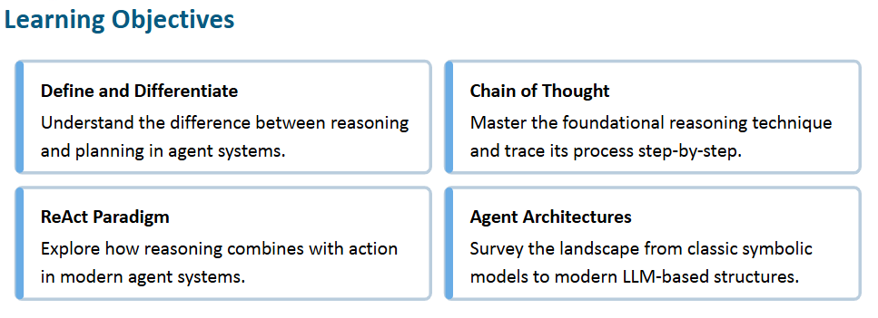

## Learning Objectives

### Define and Differentiate

- Understand the distinction between **reasoning** and **planning** in agent systems.
- **Reasoning** refers to the cognitive process by which an agent interprets information, draws conclusions, and makes decisions based on available data and internal models.
- **Planning** involves determining a sequence of actions that leads from an initial state to a desired goal state.
- Key distinction:
  - Reasoning answers: *“What should I do and why?”*
  - Planning answers: *“How do I achieve this goal step-by-step?”*
- In agent systems:
  - Reasoning may involve inference, logic, or probabilistic thinking.
  - Planning typically involves search algorithms, optimization, or policy generation.

### Chain of Thought

- A foundational prompting and reasoning technique in large language models.
- Encourages models to generate intermediate reasoning steps before producing a final answer.
- Instead of direct answers, the model follows a structured process:
  - Break down the problem
  - Solve subcomponents
  - Aggregate results
- General structure: $$ \text{Problem} \rightarrow \text{Intermediate Steps} \rightarrow \text{Final Answer} $$
- Benefits:
  - Improves accuracy in complex reasoning tasks
  - Enhances transparency and interpretability
  - Reduces hallucination by enforcing logical progression

### ReAct Paradigm

- Combines **reasoning** and **acting** in an iterative loop within agent systems.
- ReAct stands for: $$ \text{Reasoning} + \text{Action} $$
- Core idea:
  - The agent alternates between thinking (reasoning) and interacting with the environment (actions/tools).
- Typical loop: $$ \text{Thought} \rightarrow \text{Action} \rightarrow \text{Observation} \rightarrow \text{Thought} $$
- Components:
  - **Thought**: Internal reasoning step
  - **Action**: External operation (API call, retrieval, tool use)
  - **Observation**: Result of the action
- Advantages:
  - Enables dynamic decision-making
  - Integrates external knowledge sources
  - Improves performance on multi-step tasks

### Agent Architectures

- Overview of different ways to structure intelligent agents.
- Spectrum of architectures:
  1. **Symbolic / Classical Agents**
     - Based on rules, logic, and predefined knowledge
     - Examples: expert systems, rule-based planners
  2. **Reactive Agents**
     - Respond directly to stimuli without internal models
     - Fast but limited in long-term reasoning
  3. **Deliberative Agents**
     - Maintain internal representations and perform planning
     - Use reasoning to evaluate future actions
  4. **Hybrid Architectures**
     - Combine reactive and deliberative approaches
     - Balance speed and intelligence
  5. **LLM-Based Agents**
     - Use large language models for reasoning and decision-making
     - Integrate tools, memory, and planning mechanisms
- Modern trend: $$ \text{LLM} + \text{Tools} + \text{Memory} + \text{Planning} \rightarrow \text{Agent System} $$
- Key considerations:
  - Scalability
  - Interpretability
  - Tool integration
  - Autonomy vs control

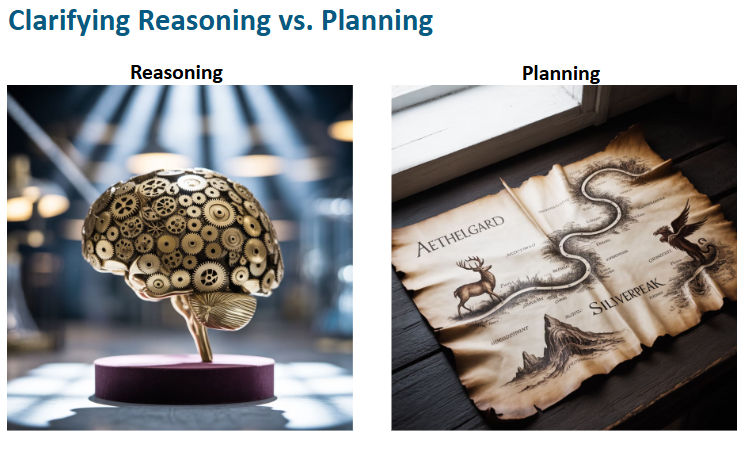

## Clarifying Reasoning vs. Planning

### Reasoning

- **Reasoning** is the internal cognitive process by which an agent interprets information, evaluates possibilities, and derives conclusions.
- It focuses on *understanding* rather than acting:
  - Interpreting inputs
  - Drawing logical inferences
  - Evaluating uncertainty
  - Making decisions based on available knowledge
- In AI systems, reasoning can involve:
  - Logical deduction
  - Probabilistic inference
  - Pattern recognition
  - Step-by-step problem solving (e.g., Chain-of-Thought)
- Abstract representation: $$ \text{Input} \rightarrow \text{Inference Process} \rightarrow \text{Conclusion} $$
- Example:
  - Given: “All humans are mortal. Socrates is human.”
  - Reasoning: $$ \text{Socrates} \in \text{Humans} \land \text{Humans} \rightarrow \text{Mortal} \Rightarrow \text{Socrates is mortal} $$
- Key characteristics:
  - Internal process (not necessarily visible externally)
  - Focused on correctness and coherence
  - May not directly produce actions

### Planning

- **Planning** is the process of determining a sequence of actions required to achieve a specific goal.
- It focuses on *execution strategy*:
  - Defining goals
  - Identifying intermediate steps
  - Sequencing actions
  - Optimizing paths
- In AI systems, planning often involves:
  - Search algorithms (e.g., BFS, A*)
  - Optimization techniques
  - Policy generation
  - Task decomposition
- Abstract representation: $$ \text{Initial State} \rightarrow \text{Action Sequence} \rightarrow \text{Goal State} $$
- Example:
  - Goal: “Travel from City A to City B”
  - Plan: $$ \text{A} \rightarrow \text{Drive to Airport} \rightarrow \text{Fly} \rightarrow \text{Taxi} \rightarrow \text{B} $$
- Key characteristics:
  - Action-oriented
  - Explicit sequence of steps
  - Goal-driven and future-focused

### Key Differences

| Aspect | Reasoning | Planning |
| --- | --- | --- |
| Focus | Understanding and inference | Action sequencing and execution |
| Output | Conclusions or decisions | Ordered set of actions |
| Nature | Internal cognitive process | External, actionable strategy |
| Time Horizon | Often immediate or local | Future-oriented |
| Example | Logical deduction | Route optimization |

### Relationship Between Reasoning and Planning

- Reasoning and planning are complementary processes in agent systems.
- Reasoning informs planning: $$ \text{Reasoning} \rightarrow \text{Better Decisions} \rightarrow \text{Effective Plans} $$
- Planning may require reasoning at each step: $$ \text{Plan Step}_i \rightarrow \text{Reasoning} \rightarrow \text{Next Step} $$
- In modern agentic AI:
  - Reasoning enables adaptability
  - Planning enables goal completion
  - Together they form intelligent behavior systems

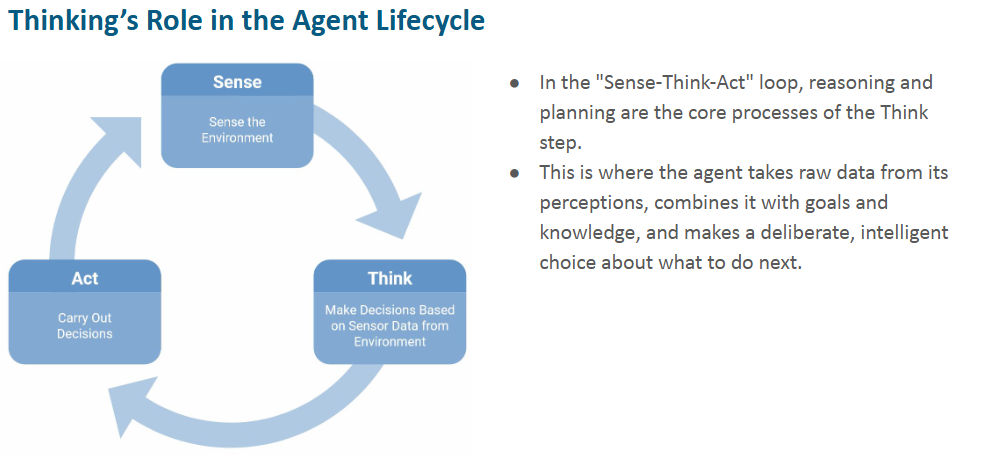

## Thinking’s Role in the Agent Lifecycle

### Sense–Think–Act Loop

- Agent systems operate through a continuous feedback loop:

  $$ \text{Sense} \rightarrow \text{Think} \rightarrow \text{Act} \rightarrow \text{Sense} \rightarrow \dots $$
- This loop enables agents to:
  - Continuously adapt to changing environments
  - Update decisions based on new information
  - Improve performance over time

### Sense Phase

- The **Sense** phase is responsible for gathering information from the environment.
- Inputs may include:
  - Sensor data (in robotics)
  - User input (in conversational agents)
  - Retrieved documents or API responses (in LLM agents)
- Output: $$ \text{Environment Data} \rightarrow \text{Perception Representation} $$
- This phase defines *what the agent knows at a given moment*.

### Think Phase

- The **Think** phase is the core of agent intelligence.
- It is where **reasoning** and **planning** occur:
  - Reasoning interprets and evaluates the sensed data
  - Planning determines the sequence of actions to achieve goals
- Process: $$ \text{Perception} + \text{Knowledge} + \text{Goals} \rightarrow \text{Decision} $$
- Key components:
  - **Reasoning**
    - Analyze current state
    - Infer hidden information
    - Evaluate options
  - **Planning**
    - Decompose goals into steps
    - Predict outcomes of actions
    - Select optimal or feasible action sequence
- In modern LLM-based agents:
  - This phase may involve Chain-of-Thought reasoning
  - Tool selection and orchestration
  - Memory retrieval and context integration
- Outcome:
  - A deliberate, informed decision about the next action

### Act Phase

- The **Act** phase executes the decisions made during the Think phase.
- Actions may include:
  - Calling APIs or tools
  - Generating responses
  - Updating memory
  - Interacting with external systems
- Representation: $$ \text{Decision} \rightarrow \text{Action Execution} \rightarrow \text{Environment Change} $$
- The environment is modified, producing new data for the next cycle.

### Role of Thinking in the Lifecycle

- The **Think** phase acts as the bridge between perception and action:

  $$ \text{Sense} \rightarrow \boxed{\text{Think}} \rightarrow \text{Act} $$
- It transforms raw data into intelligent behavior by:
  - Integrating context and prior knowledge
  - Evaluating multiple possible actions
  - Selecting goal-aligned outcomes
- Without effective thinking:
  - Agents become purely reactive (no reasoning)
  - Decisions lack coherence and long-term direction

### Key Insight

- The intelligence of an agent is primarily determined by the quality of its **Think** phase:

  $$ \text{Better Thinking} \Rightarrow \text{Better Decisions} \Rightarrow \text{Better Actions} $$
- Modern agent design focuses on enhancing this phase through:
  - Advanced reasoning techniques
  - Structured planning
  - Tool augmentation
  - Memory systems

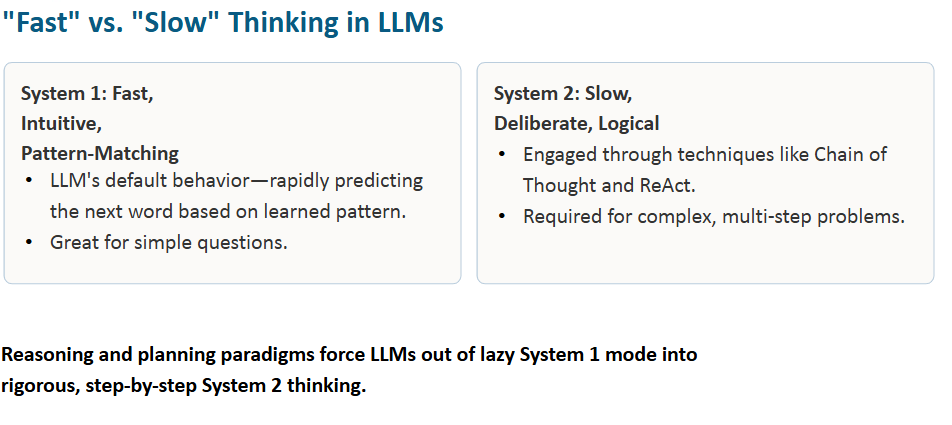

## "Fast" vs. "Slow" Thinking in LLMs

### System 1: Fast, Intuitive, Pattern-Matching

- **System 1** represents the default behavior of large language models.
- It operates through rapid pattern recognition:
  - Predicts the next token based on learned statistical patterns
  - Relies on prior training data without explicit step-by-step reasoning
- Process: $$ \text{Input} \rightarrow \text{Pattern Matching} \rightarrow \text{Immediate Output} $$
- Characteristics:
  - Fast and efficient
  - Low computational cost
  - Works well for familiar or simple tasks
- Typical use cases:
  - Basic Q&A
  - Text completion
  - Summarization
  - Common knowledge retrieval
- Limitations:
  - Prone to shallow reasoning
  - Higher risk of hallucinations
  - Struggles with multi-step or novel problems

### System 2: Slow, Deliberate, Logical

- **System 2** introduces structured, step-by-step reasoning.
- It is activated through prompting techniques and agent design patterns such as:
  - Chain of Thought (CoT)
  - ReAct (Reason + Act)
- Process: $$ \text{Input} \rightarrow \text{Step-by-Step Reasoning} \rightarrow \text{Validated Output} $$
- Characteristics:
  - Slower but more accurate
  - Deliberate and structured
  - Handles complexity and ambiguity
- Typical use cases:
  - Mathematical reasoning
  - Multi-step problem solving
  - Planning tasks
  - Tool-augmented workflows
- Benefits:
  - Improved correctness
  - Greater transparency
  - Better generalization to unseen problems

### Transition from System 1 to System 2

- Reasoning and planning paradigms shift LLM behavior:

  $$ \text{System 1} \xrightarrow{\text{Prompting / Agent Design}} \text{System 2} $$
- Techniques that enable this transition:
  - Explicit reasoning prompts ("Let's think step by step")
  - Structured outputs
  - Tool usage and intermediate steps
  - Memory and context enrichment

### Key Insight

- Effective agent systems intentionally guide LLMs away from purely reactive behavior:

  $$ \text{Fast (Reactive)} \rightarrow \text{Slow (Deliberate)} \rightarrow \text{Reliable Intelligence} $$
- Balancing both systems is critical:
  - Use **System 1** for speed and efficiency
  - Use **System 2** for accuracy and complex reasoning
- Advanced agents dynamically switch between both modes depending on task complexity.

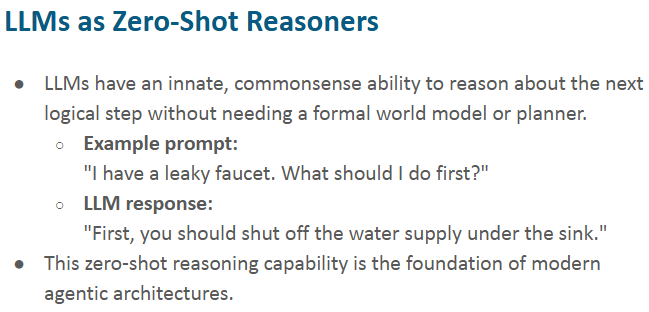

## LLMs as Zero-Shot Reasoners

### Zero-Shot Reasoning Capability

- Large Language Models (LLMs) exhibit an **innate ability to perform reasoning without explicit training on a specific task**.
- This is known as **zero-shot reasoning**:
  - The model can infer the next logical step based solely on its pre-trained knowledge
  - No examples or demonstrations are required in the prompt
- General formulation: $$ \text{Prompt} \rightarrow \text{Implicit Reasoning} \rightarrow \text{Logical Response} $$

### Example of Zero-Shot Reasoning

- **Prompt**: *"I have a leaky faucet. What should I do first?"*
- **LLM Response**: *"First, you should shut off the water supply under the sink."*
- Interpretation:
  - The model identifies the problem (leak)
  - Infers the most critical first step (stop water flow)
  - Produces a practical, goal-oriented response
- This occurs **without**:
  - A predefined rule system
  - A formal planner
  - Step-by-step instructions in the prompt

### Why Zero-Shot Reasoning Works

- LLMs are trained on vast corpora containing:
  - Instructions
  - Explanations
  - Procedural knowledge
  - Everyday problem-solving patterns
- As a result, they internalize:
  - Common-sense reasoning
  - Causal relationships
  - Action sequences
- Conceptually: $$ \text{Pretraining Knowledge} + \text{Context} \rightarrow \text{Emergent Reasoning} $$

### Limitations of Zero-Shot Reasoning

- While powerful, zero-shot reasoning has constraints:
  - May produce **shallow or incomplete reasoning**
  - Struggles with **complex, multi-step problems**
  - Can be **inconsistent** across similar queries
  - Lacks explicit verification of intermediate steps
- This is largely aligned with **System 1 (fast thinking)** behavior.

### Role in Agentic Architectures

- Zero-shot reasoning serves as the **foundation** for modern agent systems.
- It enables:
  - Immediate responsiveness
  - Basic decision-making without orchestration
  - Lightweight agents with minimal setup
- However, advanced agents extend this capability:

  $$ \text{Zero-Shot Reasoning} \rightarrow \text{Structured Reasoning} \rightarrow \text{Planning + Tool Use} $$
- Enhancements include:
  - Chain-of-Thought prompting
  - ReAct frameworks
  - Memory and retrieval integration

### Key Insight

- Zero-shot reasoning demonstrates that LLMs can act as **general-purpose reasoning engines**:

  $$ \text{General Knowledge} \Rightarrow \text{Contextual Understanding} \Rightarrow \text{Actionable Insight} $$
- It is the starting point upon which more robust, reliable, and scalable agent behaviors are built.

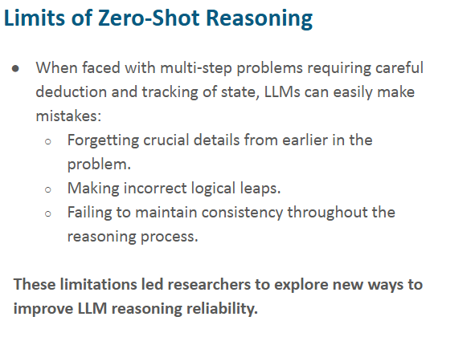

## Limits of Zero-Shot Reasoning

### Challenges in Multi-Step Reasoning

- While LLMs perform well in simple, zero-shot scenarios, they struggle with **complex, multi-step problems** that require:
  - Careful deduction
  - Tracking intermediate states
  - Maintaining logical consistency over multiple steps
- General difficulty: $$ \text{Complex Problem} \rightarrow \text{Multiple Dependencies} \rightarrow \text{Error Accumulation} $$

### Common Failure Modes

- **Forgetting Crucial Details**
  - LLMs may lose track of important information introduced earlier in the prompt
  - Especially problematic in long or stateful reasoning tasks

  $$ \text{Step}_1 \rightarrow \text{Step}_2 \rightarrow \dots \rightarrow \text{Missing Context} $$
- **Incorrect Logical Leaps**
  - The model may jump to conclusions without fully validating intermediate steps
  - Often due to reliance on pattern matching rather than structured reasoning

  $$ \text{Premises} \not\Rightarrow \text{Conclusion} $$
- **Inconsistency in Reasoning**
  - Outputs may contradict earlier statements
  - Internal reasoning paths are not guaranteed to be coherent

### Root Cause

- These limitations arise because zero-shot reasoning is primarily aligned with **System 1 (fast thinking)**:
  - No enforced step-by-step structure
  - No explicit state tracking
  - No verification mechanism
- Representation: $$ \text{Fast Reasoning} \rightarrow \text{Shallow Processing} \rightarrow \text{Higher Error Risk} $$

### Implications for Agent Design

- Pure zero-shot reasoning is insufficient for:
  - Complex workflows
  - Long-horizon planning
  - High-stakes decision-making
- This leads to the need for enhanced approaches:

  $$ \text{Zero-Shot} \rightarrow \text{Structured Reasoning} \rightarrow \text{Reliable Agents} $$

### Motivation for Improvement

- These limitations have driven research into techniques that improve reasoning reliability:
  - Chain-of-Thought prompting
  - ReAct (Reason + Act)
  - Tool-augmented reasoning
  - Memory and state tracking systems
- Goal: $$ \text{Reduce Errors} + \text{Increase Consistency} + \text{Improve Interpretability} $$

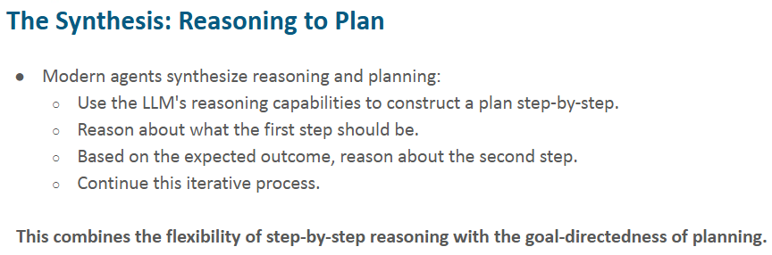

## The Synthesis: Reasoning to Plan

### Integrating Reasoning and Planning

- Modern agent systems combine **reasoning** and **planning** into a unified process.
- Instead of separating thinking and acting, agents **use reasoning to construct plans dynamically**.
- Core idea: $$ \text{Reasoning} \rightarrow \text{Plan Construction} \rightarrow \text{Action} $$

### Step-by-Step Plan Construction

- Agents leverage LLM reasoning to iteratively build a plan:
  1. **Determine the First Step**
     - Analyze the current state and goal
     - Infer the most appropriate initial action

     $$ \text{State}_0 + \text{Goal} \rightarrow \text{Action}_1 $$
  2. **Evaluate Expected Outcome**
     - Predict the result of the chosen action
     - Use reasoning to assess whether it moves toward the goal

     $$ \text{Action}_1 \rightarrow \text{Expected State}_1 $$
  3. **Derive the Next Step**
     - Based on the updated (or expected) state, determine the next action

     $$ \text{State}_1 + \text{Goal} \rightarrow \text{Action}_2 $$
  4. **Iterate the Process**
     - Continue reasoning step-by-step until the goal is achieved

### Iterative Reasoning–Planning Loop

- This creates a continuous loop where reasoning guides each planning step:

  $$ \text{Reason} \rightarrow \text{Act} \rightarrow \text{Evaluate} \rightarrow \text{Reason} $$
- Characteristics:
  - Adaptive to new information
  - Robust to uncertainty
  - Capable of revising plans dynamically

### Key Advantages

- **Flexibility**
  - Plans are not fixed; they evolve based on intermediate results
- **Robustness**
  - Errors can be corrected mid-process through re-reasoning
- **Scalability**
  - Handles complex, multi-step tasks more effectively

### Conceptual Synthesis

- This approach unifies the strengths of both paradigms:

  $$ \text{Step-by-Step Reasoning} + \text{Goal-Directed Planning} \rightarrow \text{Intelligent Agent Behavior} $$
- Reasoning provides:
  - Understanding
  - Adaptability
  - Decision quality
- Planning provides:
  - Structure
  - Direction
  - Goal alignment

### Key Insight

- Modern agents do not simply *plan then act*—they **reason their way into a plan**:

  $$ \text{Thinking} \Rightarrow \text{Planning} \Rightarrow \text{Acting} \Rightarrow \text{Refining} $$
- This synthesis is fundamental to advanced agentic AI systems, enabling more reliable and context-aware decision-making.

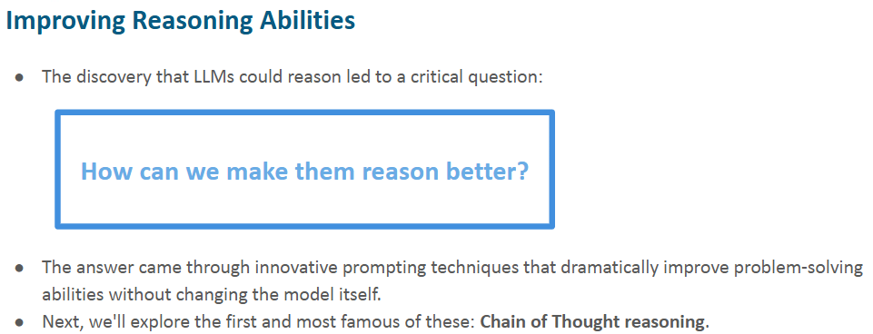

## Improving Reasoning Abilities

### The Core Question

- The discovery that LLMs can perform reasoning naturally led to a fundamental question:

  $$ \text{How can we improve the reasoning capabilities of LLMs?} $$
- This question is central to advancing agentic AI systems and unlocking more reliable, complex behaviors.

### Key Insight: Improvement Without Retraining

- A major breakthrough was realizing that **reasoning performance can be significantly improved without modifying the model itself**.
- Instead of changing the model:
  - We change **how we interact with it**
  - We design better **prompts and structures**
- Conceptually: $$ \text{Same Model} + \text{Better Prompting} \rightarrow \text{Improved Reasoning} $$

### Role of Prompting Techniques

- Prompting techniques act as **external scaffolding** for reasoning.
- They guide the model to:
  - Break down problems
  - Follow structured steps
  - Maintain logical consistency
  - Reduce errors in complex tasks
- General transformation: $$ \text{Unstructured Input} \rightarrow \text{Guided Reasoning Process} \rightarrow \text{Better Output} $$

### Why This Works

- LLMs already contain latent reasoning capabilities learned during pretraining.
- Prompting techniques:
  - Activate these capabilities
  - Constrain the model’s behavior
  - Encourage deeper, more deliberate thinking
- Representation: $$ \text{Latent Knowledge} + \text{Structured Prompt} \rightarrow \text{Enhanced Reasoning} $$

### Impact on Problem Solving

- These innovations lead to:
  - Higher accuracy in multi-step tasks
  - Better handling of ambiguity
  - Improved consistency across responses
- Especially important for:
  - Mathematical reasoning
  - Logical deduction
  - Planning and decision-making

### Transition to Advanced Techniques

- This line of research introduces structured reasoning approaches such as:
  - Chain of Thought (CoT)
  - ReAct (Reason + Act)
  - Tool-augmented reasoning
  - Memory-enhanced agents
- Evolution pathway: $$ \text{Basic Reasoning} \rightarrow \text{Guided Reasoning} \rightarrow \text{Agentic Intelligence} $$

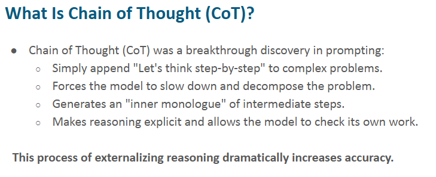

## What Is Chain of Thought (CoT)?

### Definition and Core Idea

- **Chain of Thought (CoT)** is a prompting technique that encourages LLMs to generate **explicit intermediate reasoning steps** before producing a final answer.
- It represents a major breakthrough in improving reasoning performance through simple prompt design.
- Core transformation: $$ \text{Problem} \rightarrow \text{Step-by-Step Reasoning} \rightarrow \text{Final Answer} $$

### How It Works

- A simple instruction such as:

  *“Let’s think step-by-step”*

  guides the model to:
  - Slow down its response generation
  - Decompose the problem into smaller parts
  - Explicitly articulate intermediate steps
- This shifts the model from: $$ \text{Fast (System 1)} \rightarrow \text{Deliberate (System 2)} $$

### Key Characteristics

- **Decomposition of Problems**
  - Breaks complex tasks into manageable subproblems
- **Intermediate Reasoning**
  - Produces a sequence of logical steps (an "inner monologue")
- **Self-Verification**
  - Enables the model to implicitly check earlier steps before proceeding
- **Transparency**
  - Makes the reasoning process visible and interpretable

### Example Structure

- Without CoT: $$ \text{Question} \rightarrow \text{Answer} $$
- With CoT: $$ \text{Question} \rightarrow \text{Reasoning Steps} \rightarrow \text{Answer} $$

### Why Chain of Thought Improves Accuracy

- CoT reduces common reasoning errors by:
  - Preventing premature conclusions
  - Maintaining logical consistency
  - Tracking intermediate states
- Conceptually: $$ \text{Explicit Reasoning} \rightarrow \text{Fewer Errors} \rightarrow \text{Higher Accuracy} $$

### Role in Modern AI Systems

- CoT is foundational for:
  - Advanced prompting strategies
  - Agent reasoning loops
  - Planning and decision-making systems
- It enables LLMs to function more like **structured problem solvers** rather than simple pattern matchers.

### Key Insight

- The power of CoT lies in **externalizing reasoning**:

  $$ \text{Hidden Reasoning} \rightarrow \text{Visible Reasoning} \rightarrow \text{Improved Performance} $$

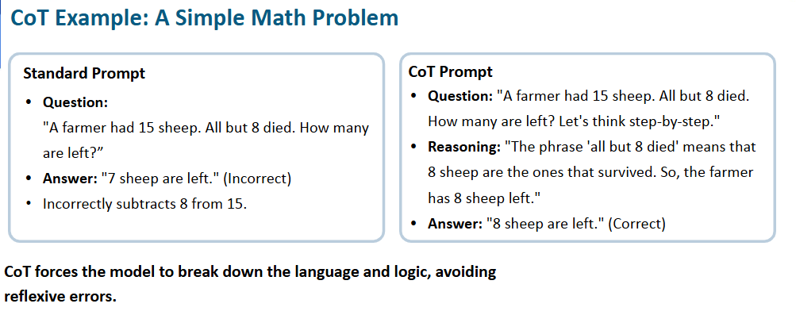

## CoT Example: A Simple Math Problem

### Standard Prompt (Without Chain of Thought)

- **Question**: *"A farmer had 15 sheep. All but 8 died. How many are left?"*
- **Model Behavior**:
  - Applies quick pattern matching
  - Interprets the problem as a subtraction task
- **Incorrect Reasoning**: $$ 15 - 8 = 7 $$
- **Answer**: *"7 sheep are left."* ❌
- **Issue**:
  - The model misinterprets the phrase **"all but 8 died"**
  - Falls into a **System 1 trap** (fast, reflexive response)

### CoT Prompt (With Chain of Thought)

- **Question**: *"A farmer had 15 sheep. All but 8 died. How many are left? Let's think step-by-step."*
- **Step-by-Step Reasoning**:
  - The phrase *"all but 8 died"* means: $$ \text{Total Sheep} - \text{Sheep That Died} = \text{Sheep Remaining} $$
  - But more precisely:
    - "All but 8 died" ⇒ **8 sheep survived**
- **Correct Interpretation**: $$ \text{Remaining Sheep} = 8 $$
- **Answer**: *"8 sheep are left."* ✅

### Why CoT Works Here

- Forces the model to:
  - Interpret language carefully
  - Avoid premature mathematical operations
  - Align reasoning with semantic meaning
- Transformation: $$ \text{Ambiguous Language} \rightarrow \text{Explicit Reasoning} \rightarrow \text{Correct Answer} $$

### Key Insight

- Chain of Thought reduces **reflexive errors** by enforcing structured reasoning:

  $$ \text{Fast Guess} \rightarrow \text{Step-by-Step Analysis} \rightarrow \text{Accurate Result} $$
- Particularly effective when:
  - Problems involve tricky wording
  - Logical interpretation is required
  - Simple heuristics may fail

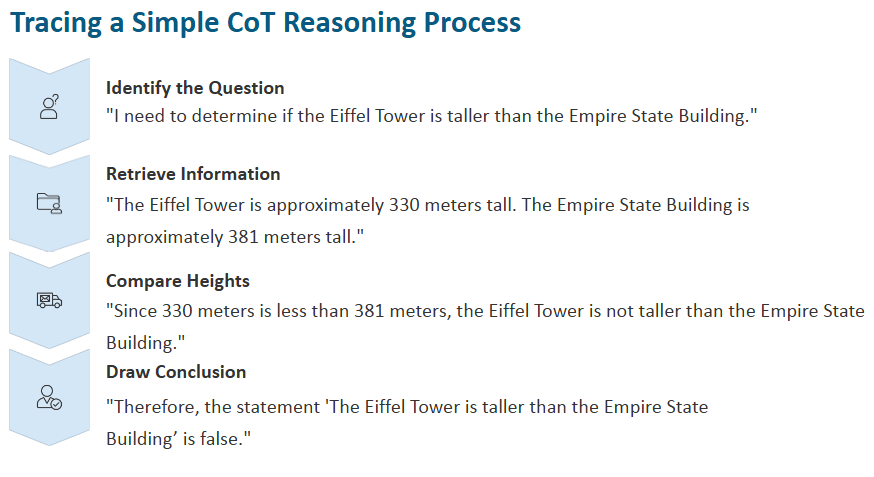

## Tracing a Simple CoT Reasoning Process

### Overview of Chain of Thought Execution

- Chain of Thought (CoT) reasoning follows a **structured sequence of intermediate steps** to arrive at a correct conclusion.
- Instead of jumping directly to an answer, the model:
  - Identifies the task
  - Gathers relevant information
  - Performs comparisons or transformations
  - Derives a final conclusion
- General structure: $$ \text{Question} \rightarrow \text{Information Retrieval} \rightarrow \text{Reasoning} \rightarrow \text{Conclusion} $$

### Step 1: Identify the Question

- Clearly define the problem to be solved.
- Example:
  - *"I need to determine if the Eiffel Tower is taller than the Empire State Building."*
- Purpose:
  - Establish the **goal of reasoning**
  - Frame the comparison task
- Representation: $$ \text{Goal} = \text{Compare Height(Eiffel Tower, Empire State Building)} $$

### Step 2: Retrieve Information

- Gather relevant facts required to solve the problem.
- Example:
  - Eiffel Tower height ≈ 330 meters
  - Empire State Building height ≈ 381 meters
- Purpose:
  - Provide the **data needed for reasoning**
  - Ensure decisions are grounded in factual knowledge
- Representation: $$ h_{Eiffel} = 330,\quad h_{Empire} = 381 $$

### Step 3: Compare Heights

- Perform the necessary reasoning or computation.
- Example:
  - Compare the two values: $$ 330 < 381 $$
- Interpretation:
  - The Eiffel Tower is **shorter** than the Empire State Building
- Purpose:
  - Transform raw data into meaningful insight
  - Apply logical or numerical comparison

### Step 4: Draw Conclusion

- Use the reasoning result to answer the original question.
- Example:
  - Since $330 < 381$, the statement is false
- Final conclusion: $$ \text{Height(Eiffel)} < \text{Height(Empire)} \Rightarrow \text{Statement is False} $$
- Purpose:
  - Deliver a clear, justified answer
  - Ensure alignment with the original goal

### Key Characteristics of This Process

- **Sequential Reasoning**
  - Each step builds on the previous one
- **Explicit Intermediate States**
  - All relevant information is surfaced and used
- **Reduced Error Risk**
  - Prevents skipping critical steps
- **Interpretability**
  - The reasoning process can be inspected and validated

### Conceptual Insight

- Chain of Thought transforms reasoning into a structured pipeline:

  $$ \text{Raw Question} \rightarrow \text{Structured Thinking} \rightarrow \text{Reliable Answer} $$
- This approach is essential for:
  - Multi-step reasoning tasks
  - Logical comparisons
  - Decision-making in agent systems

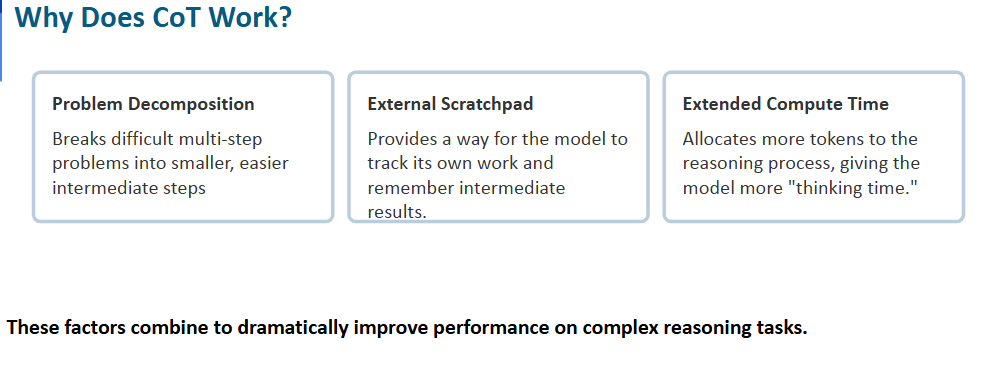

## Why Does CoT Work?

### Problem Decomposition

- Chain of Thought (CoT) improves reasoning by **breaking complex problems into smaller, manageable steps**.
- Instead of solving everything at once, the model handles:
  - Subproblems sequentially
  - Simpler intermediate tasks
- Representation: $$ \text{Complex Problem} \rightarrow {\text{Step}_1, \text{Step}_2, \dots, \text{Step}_n} $$
- Benefits:
  - Reduces cognitive load
  - Minimizes errors from skipping steps
  - Improves clarity in reasoning

### Extended Compute Time

- CoT increases the number of tokens used during reasoning, effectively giving the model more **“thinking time.”**
- Instead of producing a quick answer:
  - The model generates intermediate reasoning tokens
  - Allocates more computation to problem solving
- Representation: $$ \text{More Tokens} \Rightarrow \text{More Computation} \Rightarrow \text{Better Reasoning} $$
- Benefits:
  - Allows deeper exploration of the problem
  - Reduces premature conclusions
  - Improves accuracy on complex tasks

### Combined Effect

  $$ \text{Decomposition} + \text{Memory (Scratchpad)} + \text{Compute Time} \rightarrow \text{Improved Accuracy} $$
- Outcome:
  - Better handling of multi-step problems
  - Increased logical consistency
  - Reduced error rates

### Key Insight

- Chain of Thought transforms LLM reasoning from a **single-step prediction process** into a **structured, multi-step computation**:

  $$ \text{One-Step Guess} \rightarrow \text{Multi-Step Reasoning} \rightarrow \text{Reliable Output} $$

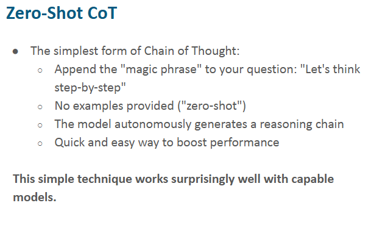

## Zero-Shot Chain of Thought (Zero-Shot CoT)

### Definition

- **Zero-Shot CoT** is the simplest form of Chain of Thought prompting.
- It enables reasoning by adding a minimal instruction to the prompt, without providing examples.
- Core idea: $$ \text{Question} + \text{"Let's think step-by-step"} \rightarrow \text{Reasoning Chain} \rightarrow \text{Answer} $$

### Key Mechanism

- The technique relies on a **trigger phrase** such as:

  *“Let’s think step-by-step”*
- This phrase encourages the model to:
  - Slow down
  - Decompose the problem
  - Generate intermediate reasoning steps automatically
- Representation: $$ \text{Simple Prompt} \rightarrow \text{Guided Reasoning Behavior} $$

### Characteristics

- **No Examples Required**
  - Unlike few-shot prompting, no demonstrations are needed
  - The model relies entirely on its internal knowledge
- **Autonomous Reasoning**
  - The model generates its own reasoning chain
  - No predefined structure is enforced
- **Lightweight and Efficient**
  - Minimal prompt engineering effort
  - Easy to apply across tasks

### Why It Works

- Zero-Shot CoT activates **latent reasoning abilities** already present in the model.
- It shifts behavior from: $$ \text{Direct Answering} \rightarrow \text{Step-by-Step Reasoning} $$
- This improves:
  - Logical consistency
  - Multi-step problem solving
  - Accuracy in complex tasks

### Advantages

- **Simplicity**
  - Easy to implement in any prompt
- **Generality**
  - Works across domains without customization
- **Performance Boost**
  - Provides immediate improvement over standard prompting

### Limitations

- Less controlled compared to structured CoT or few-shot CoT
- Reasoning quality may vary across tasks
- Still prone to errors in highly complex scenarios

### Key Insight

- Zero-Shot CoT demonstrates that **small prompt changes can unlock significant reasoning improvements**:

  $$ \text{Minimal Prompt Change} \Rightarrow \text{Significant Performance Gain} $$

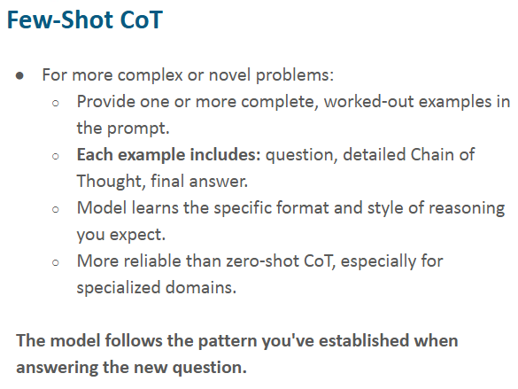

## Few-Shot Chain of Thought (Few-Shot CoT)

### Definition

- **Few-Shot CoT** extends Chain of Thought prompting by providing **worked examples** in the prompt.
- These examples demonstrate:
  - How to reason step-by-step
  - How to structure intermediate steps
  - How to arrive at the final answer
- Core formulation: $$ \text{Examples (Reasoning + Answers)} + \text{New Question} \rightarrow \text{Guided Reasoning} \rightarrow \text{Answer} $$

### Why It Works

- Few-shot examples act as **implicit instructions** that guide the model’s behavior.
- The model performs **pattern imitation**:
  - Recognizes the structure of reasoning
  - Applies the same structure to new problems
- Representation: $$ \text{Demonstrated Pattern} \rightarrow \text{Pattern Generalization} \rightarrow \text{Improved Reasoning} $$

### Advantages Over Zero-Shot CoT

- **Higher Reliability**
  - More consistent reasoning across tasks
- **Better Performance on Complex Problems**
  - Especially useful for multi-step or ambiguous tasks
- **Domain Adaptability**
  - Can tailor reasoning style to specific domains (e.g., math, coding, legal)
- Comparison: $$ \text{Few-Shot CoT} > \text{Zero-Shot CoT} \quad \text{(in complex scenarios)} $$

### Key Characteristics

- **Structured Guidance**
  - Explicit examples define expectations
- **Controlled Reasoning Style**
  - Reduces variability in outputs
- **Improved Generalization**
  - Helps the model adapt to unfamiliar tasks

### Limitations

- Requires careful design of examples
- Increases prompt length (higher token usage)
- Performance depends on quality and relevance of examples

### Key Insight

- Few-Shot CoT works by **teaching through demonstration**:

  $$ \text{Show the Model How to Think} \Rightarrow \text{Model Thinks Better} $$
- The model follows the reasoning pattern established in the prompt when solving new problems.

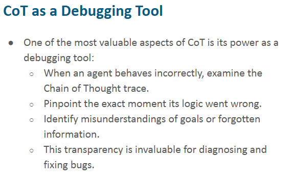

## CoT as a Debugging Tool

### Chain of Thought for Error Analysis

- One of the most powerful applications of Chain of Thought (CoT) is its ability to act as a **debugging mechanism** for agent behavior.
- By exposing intermediate reasoning steps, CoT allows us to:
  - Inspect how a conclusion was reached
  - Identify where the reasoning deviated from correctness
- General concept: $$ \text{Reasoning Trace} \rightarrow \text{Error Identification} \rightarrow \text{Correction} $$

### Diagnosing Incorrect Behavior

- When an agent produces an incorrect output:
  - Examine the **Chain of Thought trace**
  - Follow each step in sequence
  - Locate the exact step where the logic breaks
- Representation: $$ \text{Step}_1 \rightarrow \text{Step}_2 \rightarrow \text{Step}_k \ (\text{Error}) \rightarrow \text{Incorrect Output} $$
- This enables precise debugging rather than guessing the cause.

### Common Issues Identified via CoT

- **Logical Errors**
  - Incorrect inference or flawed reasoning step
- **Misinterpretation of the Problem**
  - The agent misunderstands the question or constraints
- **Missing or Forgotten Information**
  - Key details from earlier steps are not used
- **Goal Misalignment**
  - The reasoning diverges from the intended objective

### Benefits of Transparency

- CoT provides **visibility into the internal decision-making process**.
- Advantages:
  - Easier to validate correctness
  - Faster identification of bugs
  - Improved trust in model outputs
- Conceptual flow: $$ \text{Opaque Output} \rightarrow \text{Transparent Reasoning} \rightarrow \text{Explainability} $$

### Improving Agent Reliability

- Once errors are identified, they can be addressed by:
  - Refining prompts
  - Adding constraints or structure
  - Introducing few-shot examples
  - Incorporating validation steps
- Iterative improvement: $$ \text{Error Detection} \rightarrow \text{Prompt Adjustment} \rightarrow \text{Better Reasoning} $$

### Key Insight

- Chain of Thought transforms debugging from **black-box inspection** to **step-by-step diagnosis**:

  $$ \text{Hidden Process} \rightarrow \text{Visible Steps} \rightarrow \text{Actionable Fixes} $$

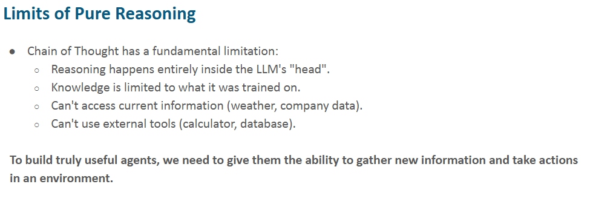

## Limits of Pure Reasoning

### Fundamental Limitation of Chain of Thought

- While Chain of Thought (CoT) enhances reasoning, it remains constrained by a key limitation:
  - All reasoning occurs **internally within the model**
  - No interaction with the external world
- Representation: $$ \text{Internal Reasoning Only} \rightarrow \text{Limited Capabilities} $$

### Knowledge Boundaries

- LLMs rely entirely on **pretrained knowledge**.
- Constraints:
  - No access to real-time or updated information
  - Limited to patterns and data seen during training
- Examples of unavailable information:
  - Current weather
  - Latest company metrics
  - Recent events
- Representation: $$ \text{Training Data} \neq \text{Real-Time Knowledge} $$

### Lack of External Interaction

- Pure reasoning systems cannot:
  - Query databases
  - Use calculators
  - Call APIs
  - Interact with tools or environments
- Limitation: $$ \text{No Tools} \Rightarrow \text{No External Validation or Action} $$

### Consequences for Agent Design

- These limitations restrict the usefulness of pure reasoning for real-world tasks:
  - Inability to verify results
  - Inability to fetch missing data
  - Inability to act on decisions
- Result: $$ \text{Reasoning Alone} \rightarrow \text{Incomplete Solutions} $$

### Need for Augmented Agents

- To overcome these constraints, agents must be extended with:
  - **Tool usage** (APIs, calculators, databases)
  - **Memory systems** (persistent context)
  - **Environment interaction** (actions and feedback loops)
- Evolution: $$ \text{Pure Reasoning} \rightarrow \text{Reasoning + Tools + Action} \rightarrow \text{Agent Systems} $$

### Key Insight

- Reasoning is necessary but not sufficient for intelligent behavior:

  $$ \text{Reasoning} + \text{External Capabilities} \rightarrow \text{Practical Intelligence} $$
- Truly effective agents must **think, gather information, and act** within their environment.

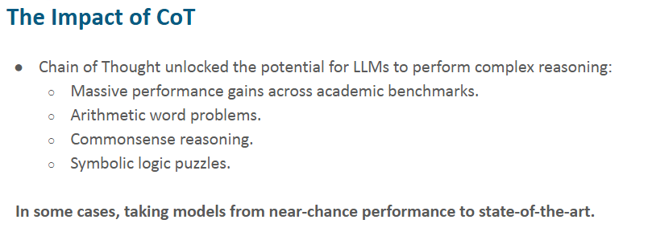

## The Impact of Chain of Thought (CoT)

### Unlocking Complex Reasoning

- Chain of Thought (CoT) significantly expanded the ability of LLMs to handle **complex reasoning tasks**.
- By introducing structured, step-by-step thinking, CoT enables models to move beyond simple pattern matching.
- Transformation: $$ \text{Shallow Prediction} \rightarrow \text{Structured Reasoning} \rightarrow \text{Advanced Problem Solving} $$

### Performance Improvements

- CoT has led to **substantial gains across multiple domains**, including:
  - **Academic Benchmarks**
    - Improved scores on reasoning-heavy evaluations
    - Better performance in multi-step problem settings
  - **Arithmetic Word Problems**
    - Accurate handling of numerical relationships
    - Reduced errors in multi-step calculations
  - **Commonsense Reasoning**
    - Improved understanding of everyday scenarios
    - Better causal and contextual inference
  - **Symbolic Logic Tasks**
    - Enhanced ability to follow formal rules
    - More consistent logical deductions
- Representation: $$ \text{CoT} \Rightarrow \text{Higher Accuracy Across Domains} $$

### From Near-Chance to State-of-the-Art

- In many cases, CoT has transformed model performance:

  $$ \text{Near-Chance Performance} \rightarrow \text{State-of-the-Art Results} $$
- This shift is especially evident in:
  - Tasks requiring multiple reasoning steps
  - Problems where intermediate state tracking is critical

### Why the Impact Is So Significant

- CoT addresses core weaknesses of standard LLM behavior:
  - Reduces premature conclusions
  - Improves logical consistency
  - Enables intermediate verification
- Combined effect: $$ \text{Explicit Reasoning} + \text{Step Tracking} + \text{More Compute} \rightarrow \text{Major Performance Gains} $$

### Broader Implications

- CoT has become a foundational technique for:
  - Prompt engineering strategies
  - Agentic AI systems
  - Tool-augmented reasoning frameworks
- It demonstrates that: $$ \text{Better Interaction Design} \Rightarrow \text{Better Model Performance} $$

### Key Insight

- Chain of Thought is not just a prompting trick—it is a **paradigm shift in how LLMs are used**:

  $$ \text{Black-Box Prediction} \rightarrow \text{Transparent, Structured Intelligence} $$

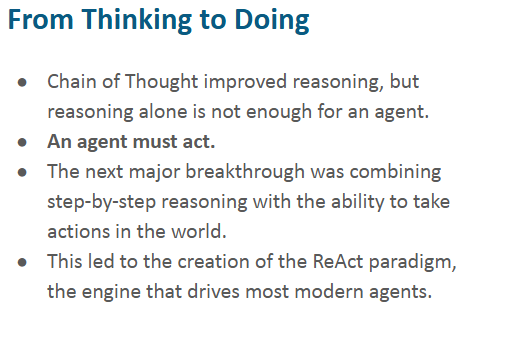

## From Thinking to Doing

### Limitation of Reasoning Alone

- Chain of Thought (CoT) significantly improves reasoning, but **reasoning by itself is not sufficient** for building effective agents.
- Key limitation: $$ \text{Reasoning Only} \rightarrow \text{No Interaction with Environment} $$
- An agent that only thinks cannot:
  - Gather new information
  - Execute tasks
  - Influence its environment

### The Need for Action

- A fundamental principle of agent systems:

  $$ \text{Agent} = \text{Perception} + \text{Reasoning} + \text{Action} $$
- Acting enables the agent to:
  - Execute decisions
  - Validate reasoning through real-world feedback
  - Progress toward goals
- Without action: $$ \text{Decision} \not\Rightarrow \text{Outcome} $$

### Bridging Thinking and Doing

- The next major advancement in agent design was combining:
  - **Step-by-step reasoning (CoT)**
  - **Action-taking capabilities (tools, APIs, environment interaction)**
- This creates a loop: $$ \text{Reason} \rightarrow \text{Act} \rightarrow \text{Observe} \rightarrow \text{Reason} $$
- This loop enables:
  - Continuous adaptation
  - Dynamic problem solving
  - Real-time decision-making

### Emergence of the ReAct Paradigm

- This integration led to the development of the **ReAct paradigm**:

  $$ \text{ReAct} = \text{Reasoning} + \text{Action} $$
- Core components:
  - **Thought** → reasoning step
  - **Action** → interaction with tools/environment
  - **Observation** → feedback from the action
- Process: $$ \text{Thought} \rightarrow \text{Action} \rightarrow \text{Observation} \rightarrow \text{Thought} $$

### Impact on Modern Agents

- ReAct is the foundation of most modern agent systems:
  - Enables tool usage (search, APIs, databases)
  - Improves accuracy through external validation
  - Supports multi-step, real-world workflows
- Evolution: $$ \text{Static Reasoning} \rightarrow \text{Interactive Agents} \rightarrow \text{Autonomous Systems} $$

### Key Insight

- True intelligence in agents emerges when **thinking is coupled with doing**:

  $$ \text{Reasoning} + \text{Action} \rightarrow \text{Effective Agent Behavior} $$
- The transition from passive reasoning to active execution is what enables agents to operate in real-world environments.